# Barriers to Health & Housing in Houston Communities

Joshua M. Garcia

This markdown demonstrates exploring and reporting alluvial diagrams of the CHW stories.

# Methods

123 respondents from Houston Communities

Mixed-methods:

- Quantitative demographic data
- Qualitative interview data
  - Problems/barriers
  - Health concerns
  - Ways that a CHW could help the individual or their family

Categorization of the qualitative data was undertaken by the research team. The project manager of CHWI provided an initial set of categories based on experience from working with CHWs. Data was coded by two research assistants. Categories were iteratively revised based on collaboration by the project team.

## Dependencies

Packages utilized can be seen here.

```r
library(tidyverse)
library(ggalluvial)
library(ggplot2)
library(hrbrthemes)
library(viridis)
library(janitor)
library(kableExtra)
```

## Preparing the Data

```r
#import data
chw_stories <- read_csv("dat.csv")
#set 9 to NA, how it was manually coded
chw_stories[chw_stories==9] <- NA
#collapse edu for alluvial aesthetics (<MS & <HS collapsed)
chw_stories$edu_4[chw_stories$edu_5 ==0] = 0
chw_stories$edu_4[chw_stories$edu_5 ==1] = 0
chw_stories$edu_4[chw_stories$edu_5 ==2] = 1
chw_stories$edu_4[chw_stories$edu_5 ==3] = 2
chw_stories$edu_4[chw_stories$edu_5 ==4] = 3
##Factor stuff for reference, will need to be rerun after grouping
chw_stories$edu_5 <- factor(chw_stories$edu_5,
                           levels = c(0,1,2,3,4),
                           labels = c("<MS","<HS","HS/GED","Some College","College+"))
chw_stories$edu_4 <- factor(chw_stories$edu_4,
                           levels = c(0,1,2,3),
                           labels = c("<HS","HS/GED","Some College","College+"))
chw_stories$gender <- factor(chw_stories$gender,
                             levels = c(1,2),
                             labels = c("Male","Female"))
chw_stories$age_4 <- factor(chw_stories$age_4,
                             levels = c(1,2,3,4),
                             labels = c("18-24","25-44","45-64","65+"))
chw_stories$race <- factor(chw_stories$race,
                            levels = c(1,2,3,4,5,6),
                            labels = c("White","Black","Asian","Latinx","MENA","Other"))
chw_stories$needs_access_transportation <- factor(chw_stories$needs_access_transportation,
                            levels = c(1,2),
                            labels = c("Yes","No/NA"))
chw_stories$familial_social_support <- factor(chw_stories$familial_social_support,
                            levels = c(1,2),
                            labels = c("Available","Unavailable"))
chw_stories$housing_3 <- factor(chw_stories$housing_3,
                            levels = c(1,2,3),
                            labels = c("Stable/Healthy","Unstable/Unhealthy","Homeless"))
chw_stories$home_unhealthy <- factor(chw_stories$home_unhealthy,
                            levels = c(1,2),
                            labels = c("No", "Yes"))
chw_stories$employ_7 <- factor(chw_stories$employ_7,
                            levels = c(1,2,3,4,5,6,7),
                            labels = c("Full time","Part time","Looking","Unable to work","Not Looking","Student","Retired"))
chw_stories$unfair_housing <- factor(chw_stories$unfair_housing,
                                     levels = c(1,2),
                                     labels = c("Yes", "No/NA"))
chw_stories$access_transportation <- factor(chw_stories$access_transportation,
                                     levels = c(1,2),
                                     labels = c("Yes", "No"))
chw_stories$interpersonal_violence <- factor(chw_stories$interpersonal_violence,
                                     levels = c(1,2),
                                     labels = c("Yes", "No/NA"))
chw_stories$school_violence <- factor(chw_stories$school_violence,
                                     levels = c(1,2),
                                     labels = c("Yes", "No/NA"))
chw_stories$health_insurance <- factor(chw_stories$health_insurance,
                                     levels = c(1,2),
                                     labels = c("Yes", "No"))
chw_stories$access_medication <- factor(chw_stories$access_medication,
                                     levels = c(1,2),
                                     labels = c("Yes", "No"))
chw_stories$health_physical_condition <- factor(chw_stories$health_physical_condition,
                                     levels = c(1,2,3),
                                     labels = c("Yes", "No/NA", "No Access to Doctor"))
chw_stories$health_edu_access <- factor(chw_stories$health_edu_access,
                                     levels = c(1,2),
                                     labels = c("Needed", "NA"))
chw_stories$needs_access_healthyfood <- factor(chw_stories$needs_access_healthyfood,
                                     levels = c(1,2),
                                     labels = c("Yes", "No/NA"))
```

# Descriptive Statistics

I conduct descriptive frequencies of the data utilizing the janitor package. I then transfer values into a summary table.

```r
#Sample Demographics ## DOUBLE check work against frequencies
#Create table
table_demo = matrix(NA, nrow = 41, ncol = 3)
##create column names
colnames(table_demo) = c("Sample demographics", "Frequency", "Percent")
#Transfer information
#Gender
freq_gender <- tabyl(chw_stories$gender, sort = TRUE)
table_demo[1, ] = c("Gender", "", "")
table_demo[2, ] = c("Male", freq_gender[1,2], round(100*freq_gender[1,3], 1))
table_demo[3, ] = c("Female", freq_gender[2,2], round(100*freq_gender[2,3], 1))
#Age
freq_age_4 <- tabyl(chw_stories$age_4, sort = TRUE)
table_demo[4, ] = c("Age", "", "")
table_demo[5, ] = c("18-24", freq_age_4[1,2], round(100*freq_age_4[1,3], 1))
table_demo[6, ] = c("25-44", freq_age_4[2,2], round(100*freq_age_4[2,3], 1))
table_demo[7, ] = c("45-64", freq_age_4[3,2], round(100*freq_age_4[3,3], 1))
table_demo[8, ] = c("65+", freq_age_4[4,2], round(100*freq_age_4[4,3], 1))
#Race
freq_race <- tabyl(chw_stories$race, sort = TRUE)
table_demo[9, ] = c("Race/Ethnicity", "", "")
table_demo[10, ] = c("White", freq_race[1,2], round(100*freq_race[1,3], 1))
table_demo[11, ] = c("Black", freq_race[2,2], round(100*freq_race[2,3], 1))
table_demo[12, ] = c("Asian", freq_race[3,2], round(100*freq_race[3,3], 1))
table_demo[13, ] = c("Latinx", freq_race[4,2], round(100*freq_race[4,3], 1))
table_demo[14, ] = c("MENA", freq_race[5,2], round(100*freq_race[5,3], 1))
table_demo[15, ] = c("Other", freq_race[6,2], round(100*freq_race[6,3], 1))
#Edu
freq_edu_5 <- tabyl(chw_stories$edu_5, sort = TRUE)
table_demo[16, ] = c("Education", "", "")
table_demo[17, ] = c("<MS", freq_edu_5[1,2], round(100*freq_edu_5[1,3], 1))
table_demo[18, ] = c("<HS", freq_edu_5[2,2], round(100*freq_edu_5[2,3], 1))
table_demo[19, ] = c("HS/GED", freq_edu_5[3,2], round(100*freq_edu_5[3,3], 1))
table_demo[20, ] = c("Some College", freq_edu_5[4,2], round(100*freq_edu_5[4,3], 1))
table_demo[21, ] = c("College", freq_edu_5[5,2], round(100*freq_edu_5[5,3], 1))
table_demo[22, ] = c("Missing", freq_edu_5[6,2], round(100*freq_edu_5[6,3], 1))
#Employment
freq_employ_7 <- tabyl(chw_stories$employ_7, sort = TRUE)
table_demo[23, ] = c("Employment", "", "")
table_demo[24, ] = c("Full time", freq_employ_7[1,2], round(100*freq_employ_7[1,3], 1))
table_demo[25, ] = c("Part time", freq_employ_7[2,2], round(100*freq_employ_7[2,3], 1))
table_demo[26, ] = c("Looking", freq_employ_7[3,2], round(100*freq_employ_7[3,3], 1))
table_demo[27, ] = c("Not Looking", freq_employ_7[5,2], round(100*freq_employ_7[5,3], 1))
table_demo[28, ] = c("Unable to Work", freq_employ_7[4,2], round(100*freq_employ_7[4,3], 1))
table_demo[29, ] = c("Student", freq_employ_7[6,2], round(100*freq_employ_7[6,3], 1))
table_demo[30, ] = c("Retired", freq_employ_7[7,2], round(100*freq_employ_7[7,3], 1))
table_demo[31, ] = c("Missing", freq_employ_7[8,2], round(100*freq_employ_7[8,3], 1))
#Income
freq_income <- tabyl(chw_stories$income, sort = TRUE)
table_demo[32, ] = c("Income", "", "")
table_demo[33, ] = c("<$20,000", freq_income[3,2], round(100*freq_income[3,3], 1))
table_demo[34, ] = c("$20,000-$34,999", freq_income[1,2], round(100*freq_income[1,3], 1))
table_demo[35, ] = c("$35,000-$49,999", freq_income[2,2], round(100*freq_income[2,3], 1))
table_demo[36, ] = c("Missing", freq_income[4,2], round(100*freq_income[4,3], 1))
#Housing
freq_housing_3 <- tabyl(chw_stories$housing_3, sort = TRUE)
table_demo[37, ] = c("Housing", "", "")
table_demo[38, ] = c("Stable/Healthy", freq_housing_3[1,2], round(100*freq_housing_3[1,3], 1))
table_demo[39, ] = c("Unstable/Unhealthy", freq_housing_3[2,2], round(100*freq_housing_3[2,3], 1))
table_demo[40, ] = c("Homeless", freq_housing_3[3,2], round(100*freq_housing_3[3,3], 1))
table_demo[41, ] = c("Missing", freq_housing_3[4,2], round(100*freq_housing_3[4,3], 1))
df_demo <- as_tibble(table_demo)
```

# Table 1: Sample demographics

| Sample demographics | Frequency | Percent |
| --- | --- | --- |
| Gender |  |  |
| Male | 40 | 32.5 |
| Female | 83 | 67.5 |
| Age |  |  |
| 18-24 | 12 | 9.8 |
| 25-44 | 74 | 60.2 |
| 45-64 | 31 | 25.2 |
| 65+ | 6 | 4.9 |
| Race/Ethnicity |  |  |
| White | 3 | 2.4 |
| Black | 113 | 91.9 |
| Asian | 1 | 0.8 |
| Latinx | 4 | 3.3 |
| MENA | 1 | 0.8 |
| Other | 1 | 0.8 |
| Education |  |  |
| <MS | 5 | 4.1 |
| <HS | 21 | 17.1 |
| HS/GED | 49 | 39.8 |
| Some College | 31 | 25.2 |
| College | 7 | 5.7 |
| Missing | 10 | 8.1 |
| Employment |  |  |
| Full time | 23 | 18.7 |
| Part time | 23 | 18.7 |
| Looking | 21 | 17.1 |
| Not Looking | 10 | 8.1 |
| Unable to Work | 35 | 28.5 |
| Student | 6 | 4.9 |
| Retired | 1 | 0.8 |
| Missing | 4 | 3.3 |
| Income |  |  |
| <$20,000 | 101 | 82.1 |
| $20,000-$34,999 | 16 | 13 |
| $35,000-$49,999 | 3 | 2.4 |
| Missing | 3 | 2.4 |
| Housing |  |  |
| Stable/Healthy | 69 | 56.1 |
| Unstable/Unhealthy | 41 | 33.3 |
| Homeless | 7 | 5.7 |
| Missing | 6 | 4.9 |

## Participant Characteristics Plot

Now, I plot the summary table data with ggplot2.

```r
#Gender
df_Gender <- df_demo  %>% slice(2:3)
colnames(df_Gender) = c("Gender", "Frequency", "Percent")
df_Gender$Percent <- as.numeric(as.character(df_Gender$Percent))
df_Gender$Gender <- factor(df_Gender$Gender,
                               levels = c("Male", "Female"))

Gender_plot <- ggplot(data=df_Gender, aes(x=Gender, y=Percent, fill=Gender)) +
    guides(fill=FALSE) +
   scale_fill_viridis(discrete=TRUE,option="D",direction = -1) +
    scale_color_viridis(discrete=TRUE,option="D",direction = -1) +
  scale_y_continuous(limits = c(0, 100)) +
   # coord_flip() +
   geom_bar(stat="identity", width = 0.5) +
geom_text(aes(label=Percent), nudge_y = 8, size=7) +
     xlab("") +
    theme_ipsum_rc(axis_text_size = 14,plot_title_size = 25) +
  ggtitle("Gender")

ggsave('Gender_plot.png',Gender_plot, width = 7.5, height = 5, units = "in")

#age_4
df_age_4 <- df_demo  %>% slice(5:8)
colnames(df_age_4) = c("age_4", "Frequency", "Percent")
df_age_4$Percent <- as.numeric(as.character(df_age_4$Percent))
df_age_4$age_4 <- factor(df_age_4$age_4,
                               levels = c("65+","45-64","25-44","18-24"))

age_4_plot <- ggplot(data=df_age_4, aes(x=age_4, y=Percent, fill=age_4)) +
    guides(fill=FALSE) +
   scale_fill_viridis(discrete=TRUE,option="D",direction = -1) +
    scale_color_viridis(discrete=TRUE,option="D",direction = -1) +
  scale_y_continuous(limits = c(0, 100)) +
   # coord_flip() +
   geom_bar(stat="identity", width = 0.5) +
geom_text(aes(label=Percent), nudge_y = 8, size=7) +
     xlab("") +
    theme_ipsum_rc(axis_text_size = 14,plot_title_size = 25) +
   ggtitle("Age")

ggsave('age_4_plot.png',age_4_plot, width = 7.5, height = 5, units = "in")

#Race
df_Race <- df_demo  %>% slice(10:15)
colnames(df_Race) = c("Race", "Frequency", "Percent")
df_Race$Percent <- as.numeric(as.character(df_Race$Percent))
df_Race$Race <- factor(df_Race$Race,
                               levels = c("Other", "MENA", "Asian", "White", "Latinx", "Black"))

Race_plot <- ggplot(data=df_Race, aes(x=Race, y=Percent, fill=Race)) +
    guides(fill=FALSE) +
   scale_fill_viridis(discrete=TRUE,option="D",direction = -1) +
    scale_color_viridis(discrete=TRUE,option="D",direction = -1) +
  scale_y_continuous(limits = c(0, 100)) +
   # coord_flip() +
   geom_bar(stat="identity", width = 0.5) +
geom_text(aes(label=Percent), nudge_y = 8, size=7) +
     xlab("") +
    theme_ipsum_rc(axis_text_size = 14,plot_title_size = 25) +
  ggtitle("Race")

ggsave('Race_plot.png',Race_plot, width = 7.5, height = 5, units = "in")

#Education
df_Education <- df_demo  %>% slice(17:22)
colnames(df_Education) = c("Education", "Frequency", "Percent")
df_Education$Percent <- as.numeric(as.character(df_Education$Percent))
df_Education$Education <- factor(df_Education$Education,
                               levels = c("Missing", "<MS", "<HS", "HS/GED", "Some College", "College"))

Education_plot <- ggplot(data=df_Education, aes(x=Education, y=Percent, fill=Education)) +
    guides(fill=FALSE) +
   scale_fill_viridis(discrete=TRUE,option="D",direction = -1) +
    scale_color_viridis(discrete=TRUE,option="D",direction = -1) +
  scale_y_continuous(limits = c(0, 100)) +
   # coord_flip() +
   geom_bar(stat="identity", width = 0.5) +
geom_text(aes(label=Percent), nudge_y = 8, size=7) +
     xlab("") +
    theme_ipsum_rc(axis_text_size = 14,plot_title_size = 25) +
  ggtitle("Education")

ggsave('Education_plot.png',Education_plot, width = 7.5, height = 5, units = "in")

#Employment
df_Employment <- df_demo  %>% slice(24:31)
colnames(df_Employment) = c("Employment", "Frequency", "Percent")
df_Employment$Percent <- as.numeric(as.character(df_Employment$Percent))
df_Employment$Employment <- factor(df_Employment$Employment,
                               levels = c("Missing", "Retired", "Unable to Work", "Not Looking", "Looking", "Student", "Part time", "Full time"))

Employment_plot <- ggplot(data=df_Employment, aes(x=Employment, y=Percent, fill=Employment)) +
    guides(fill=FALSE) +
   scale_fill_viridis(discrete=TRUE,option="D",direction = -1) +
    scale_color_viridis(discrete=TRUE,option="D",direction = -1) +
  scale_y_continuous(limits = c(0, 100)) +
   coord_flip() +
   geom_bar(stat="identity", width = 0.5) +
geom_text(aes(label=Percent), nudge_y = 8, size=7) +
     xlab("") +
    theme_ipsum_rc(axis_text_size = 14,plot_title_size = 25) +
  ggtitle("Employment")

ggsave('Employment_plot.png',Employment_plot, width = 15, height = 5, units = "in")

#Income
df_Income <- df_demo  %>% slice(33:36)
colnames(df_Income) = c("Income", "Frequency", "Percent")
df_Income$Percent <- as.numeric(as.character(df_Income$Percent))
df_Income$Income <- factor(df_Income$Income,
                               levels = c("Missing", "$35,000-$49,999", "$20,000-$34,999", "<$20,000"))

Income_plot <- ggplot(data=df_Income, aes(x=Income, y=Percent, fill=Income)) +
    guides(fill=FALSE) +
   scale_fill_viridis(discrete=TRUE,option="D",direction = -1) +
    scale_color_viridis(discrete=TRUE,option="D",direction = -1) +
  scale_y_continuous(limits = c(0, 100)) +
   # coord_flip() +
   geom_bar(stat="identity", width = 0.5) +
geom_text(aes(label=Percent), nudge_y = 8, size=7) +
     xlab("") +
    theme_ipsum_rc(axis_text_size = 14,plot_title_size = 25) +
  ggtitle("Annual Income")

ggsave('Income_plot.png',Income_plot, width = 7.5, height = 5, units = "in")

#Housing
df_Housing <- df_demo  %>% slice(38:41)
colnames(df_Housing) = c("Housing", "Frequency", "Percent")
df_Housing$Percent <- as.numeric(as.character(df_Housing$Percent))
df_Housing$Housing <- factor(df_Housing$Housing,
                               levels = c("Missing", "Homeless", "Unstable/Unhealthy", "Stable/Healthy"))

Housing_plot <- ggplot(data=df_Housing, aes(x=Housing, y=Percent, fill=Housing)) +
    guides(fill=FALSE) +
   scale_fill_viridis(discrete=TRUE,option="D",direction = -1) +
    scale_color_viridis(discrete=TRUE,option="D",direction = -1) +
  scale_y_continuous(limits = c(0, 100)) +
   # coord_flip() +
   geom_bar(stat="identity", width = 0.5) +
    geom_text(aes(label=Percent), nudge_y = 8, size=7) +
     xlab("") +
    theme_ipsum_rc(axis_text_size = 14,plot_title_size = 25) +
  ggtitle("Housing")

ggsave('Housing_plot.png',Housing_plot, width = 7.5, height = 5, units = "in")
```

# Figure 1: Sample demographics

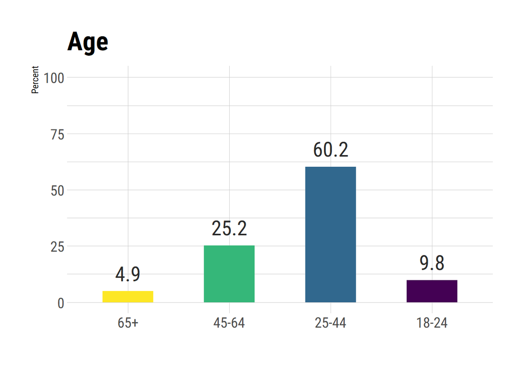

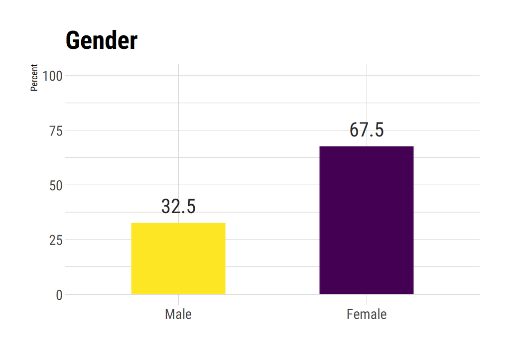

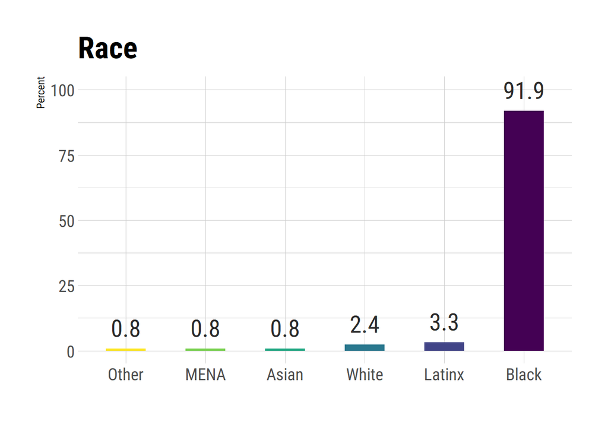

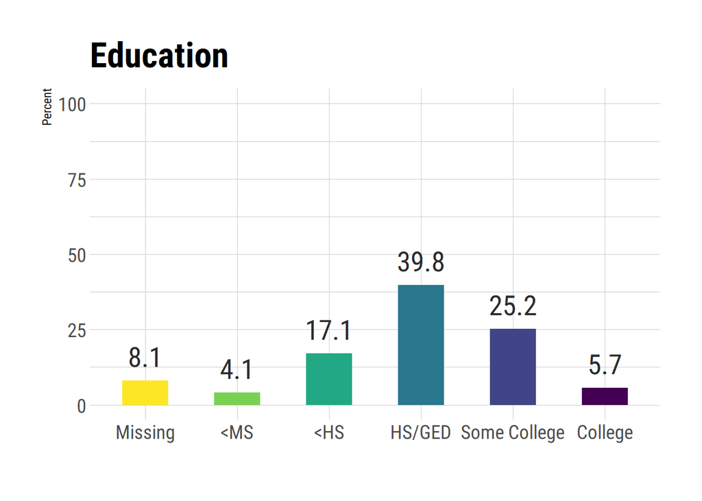

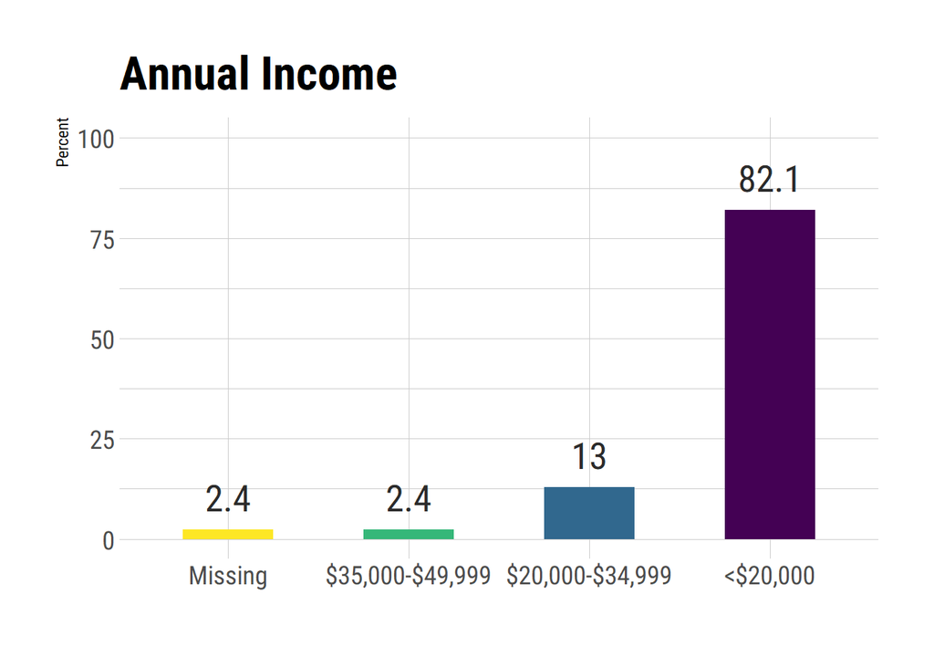

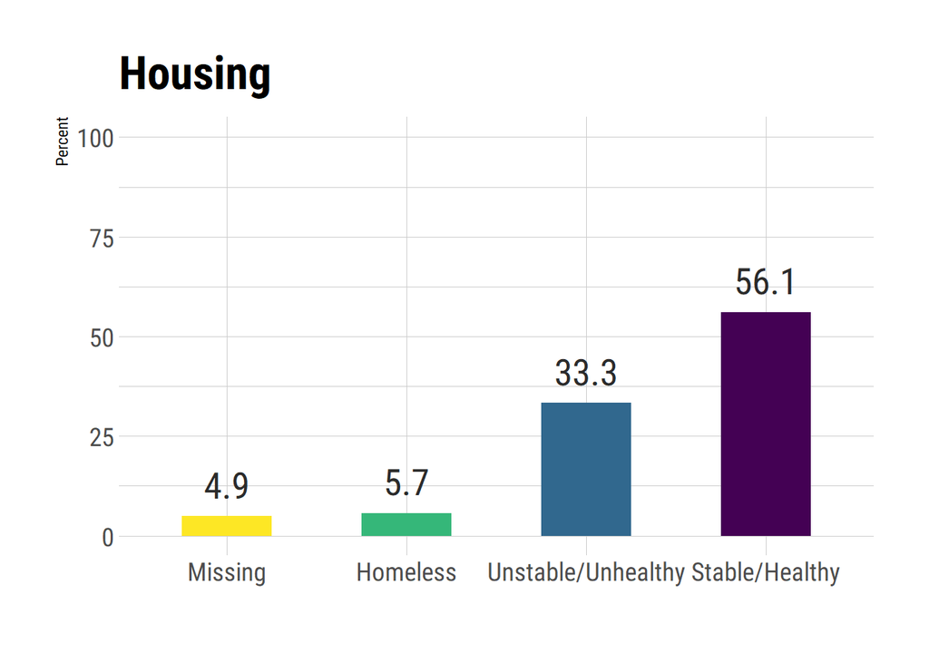

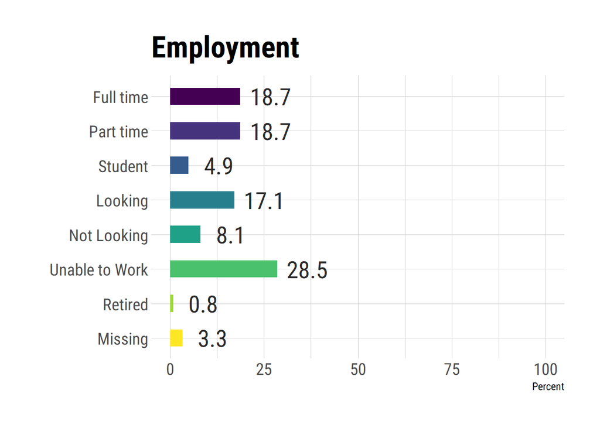

## Problems/Barriers Frequency Table

Next, I do something similar for a table on problems/barriers confronted by the sample.

```r
#Problems/Barriers Frequency Table
#Create table
table_barriers = matrix(NA, nrow = 12, ncol = 3)
##create column names
colnames(table_barriers) = c("Problems/Barriers", "Frequency", "Percent")

#calculate frequencies
freq_unfair_housing <- tabyl(chw_stories$unfair_housing, sort = TRUE)
freq_home_unhealthy <- tabyl(chw_stories$home_unhealthy, sort = TRUE)
freq_access_transportation <- tabyl(chw_stories$access_transportation, sort = TRUE)
freq_needs_access_healthyfood <- tabyl(chw_stories$needs_access_healthyfood, sort = TRUE)
freq_unfair_housing <- tabyl(chw_stories$unfair_housing, sort = TRUE)
freq_interpersonal_violence <- tabyl(chw_stories$interpersonal_violence, sort = TRUE)
freq_school_violence <- tabyl(chw_stories$school_violence, sort = TRUE)
freq_health_physical_condition <- tabyl(chw_stories$health_physical_condition, sort = TRUE)
freq_health_mental_conidition <- tabyl(chw_stories$health_mental_conidition, sort = TRUE)
freq_access_medication <- tabyl(chw_stories$access_medication, sort = TRUE)
freq_health_edu_access <- tabyl(chw_stories$health_edu_access, sort = TRUE)
freq_familial_social_support <- tabyl(chw_stories$familial_social_support, sort = TRUE)
freq_health_insurance <- tabyl(chw_stories$health_insurance, sort = TRUE)

#put table together
table_barriers[10, ] = c("Unfair Housing Practices", freq_unfair_housing[1,2], round(100*freq_unfair_housing[1,3], 1))

table_barriers[5, ] = c("Home Environment Unhealthy", freq_home_unhealthy[2,2], round(100*freq_home_unhealthy[2,3], 1))

##need to doublecheck transportation variables
table_barriers[7, ] = c("Transportation", freq_access_transportation[2,2], round(100*freq_access_transportation[2,3], 1))

table_barriers[8, ] = c("Diet", freq_needs_access_healthyfood[1,2], round(100*freq_needs_access_healthyfood[1,3], 1))

table_barriers[11, ] = c("Interpersonal Violence", freq_interpersonal_violence[1,2], round(100*freq_interpersonal_violence[1,3], 1))

table_barriers[12, ] = c("School Violence", freq_school_violence[1,2], round(100*freq_school_violence[1,3], 1))

table_barriers[3, ] = c("Physical Health Condition", freq_health_physical_condition[1,2], round(100*freq_health_physical_condition[1,3], 1))

table_barriers[9, ] = c("Mental Health Condition", freq_health_mental_conidition[1,2], round(100*freq_health_mental_conidition[1,3], 1))

table_barriers[1, ] = c("Health Insurance", freq_health_insurance[2,2], round(100*freq_health_insurance[2,3], 1))

table_barriers[6, ] = c("Medication Access", freq_access_medication[2,2], round(100*freq_access_medication[2,3], 1))

table_barriers[4, ] = c("Health Education", freq_health_edu_access[1,2], round(100*freq_health_edu_access[1,3], 1))

table_barriers[2, ] = c("Familial/Social Support", freq_familial_social_support[2,2], round(100*freq_familial_social_support[2,3], 1))

df_barriers <- as_tibble(table_barriers)
```

# Table 2: Problems/Barriers Reported

| Problems/Barriers | Frequency | Percent |
| --- | --- | --- |
| Health Insurance | 76 | 61.8 |
| Familial/Social Support | 65 | 52.8 |
| Physical Health Condition | 63 | 51.2 |
| Health Education | 56 | 45.5 |
| Home Environment Unhealthy | 33 | 26.8 |
| Medication Access | 32 | 26 |
| Transportation | 29 | 23.6 |
| Diet | 21 | 17.1 |
| Mental Health Condition | 10 | 8.1 |
| Unfair Housing Practices | 9 | 7.3 |
| Interpersonal Violence | 2 | 1.6 |
| School Violence | 2 | 1.6 |

## Problems/Barriers Bar Chart

Now, I can plot this data.

```r
colnames(df_barriers) = c("Barriers", "Frequency", "Percent")
df_barriers$Percent <- as.numeric(as.character(df_barriers$Percent))
df_barriers$Barriers <- factor(df_barriers$Barriers,
                               levels = c("School Violence","Interpersonal Violence","Unfair Housing Practices","Mental Health Condition", "Diet","Transportation", "Medication Access", "Home Environment Unhealthy","Health Education","Physical Health Condition","Familial/Social Support","Health Insurance"))

barriers_plot <- ggplot(data=df_barriers, aes(x=Barriers, y=Percent, fill=Barriers)) +
    guides(fill=FALSE) +
   scale_fill_viridis(discrete=TRUE,option="D",direction = -1) +
    scale_color_viridis(discrete=TRUE,option="D",direction = -1) +
  scale_y_continuous(limits = c(0, 65)) +
    coord_flip() +
    geom_col(stat="identity") +
    geom_text(aes(label=Percent), nudge_y = 2.75, size=8) +
  xlab("") +
  theme_ipsum_rc(axis_text_size = 30,axis_title_size = 30, plot_title_size = 45) +
  ggtitle("Problems & Barriers Reported")

ggsave('barriers_plot.png',barriers_plot, width = 25, height = 10, units = "in")
```

# Figure 2: Problems/Barriers Barplot

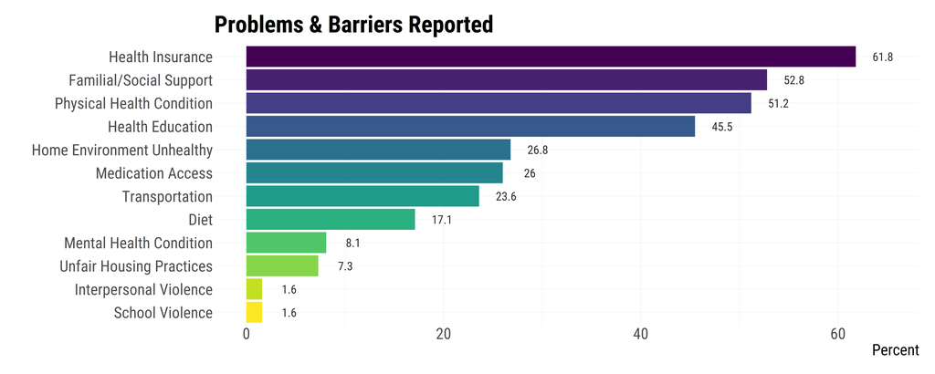

Here is an annotated version with examples:

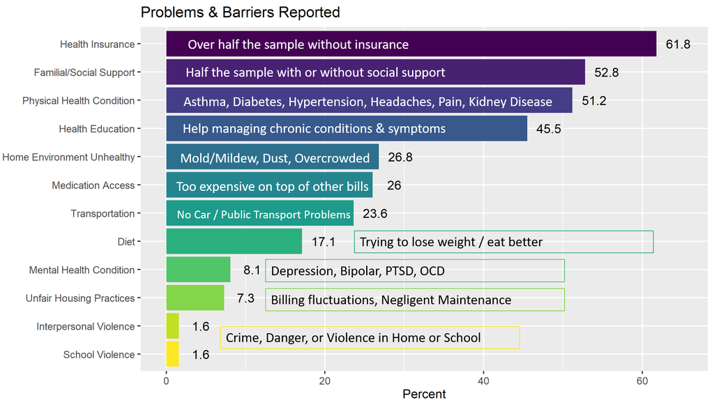

# Exploratory Alluvial Diagrams

Now, I will explore 2 alluvial diagrams using the ggalluvial. This will show us the combination of frequencies between selected variables. These combinations of frequncies could also be thought of as different pathways that individuals might take between these variables.

The alluvials will consist of:

1. Among only those in the work-force, employed “full time”, “part time”, or “unemployed-looking”: Let’s look at the pathways between education, support, employment, and housing outcomes.
2. Among only those with a physical health condition: Let’s look at the pathways between education, insurance, transportation, and medication access.

I prepare the data, run the alluvial, and save the plot in one chunk. Preparing the data involves shifting it into tabular format so that every combination of variables is represented by a row with a frequency column in addition.

## Housing Alluvial

```r
#select variables of interest
house_2 <- chw_stories %>% select(edu_4, familial_social_support, employ_7, housing_3)

#Omit mising from outcome
house_2 <- house_2 %>% drop_na(housing_3)
house_2 <- house_2 %>% filter(employ_7 == "Full time" | employ_7 == "Part time" | employ_7 == "Looking")

#calculate combinations into tabular format
input_names = names(house_2)
house_2_prep <- house_2 %>%
  count_(input_names) %>%
  unite_("ComboVar",input_names,sep=",",)

#split columns in tabular format
house_2_alluvia <- house_2_prep %>% separate(ComboVar,
                        c("edu_4","familial_social_support","employ_7","housing_3"),
                          sep = ",")
##fix column headers
colnames(house_2_alluvia) = c("Education","Support","Employment","Housing","Freq")

#plot
alluvia_housing_2_plot <- ggplot(as.data.frame(house_2_alluvia),
       aes(y = Freq,
           axis1 = Education, axis2 = Employment, axis3 = Support, axis4 = Housing)) +
      guides(fill=FALSE) +
  geom_alluvium(aes(fill = Housing), width = 1/8) +
  geom_stratum(width = 1/8, fill = "black", color = "white") +
  geom_label(stat = "stratum", aes(label = after_stat(stratum)), size = 8) +
  scale_x_discrete(limits = c("Education", "Employment", "Support", "Housing"), expand = c(.05, .05)) +
  scale_fill_viridis(discrete=TRUE,option="D",direction = 1) +
  scale_color_viridis(discrete=TRUE,option="D",direction = 1) +
  theme_ipsum_rc(axis_text_size = 30,axis_title_size = 30, plot_title_size = 45) +
  ggtitle("Housing Pathways")

ggsave('alluvia_housing_2_plot.png',alluvia_housing_2_plot, width = 25, height = 10, units = "in")
```

## Medication Access Alluvial

```r
##Subset Physical Health Condition = Yes & Medication Access No Missing
chw_med <- chw_stories %>% filter(health_physical_condition=="Yes")
chw_med <- chw_med %>% drop_na(access_medication)
chw_med <- chw_med %>% drop_na(health_physical_condition)

#select variables of interest
med_2 <- chw_med %>% select(edu_4, health_insurance, access_transportation, access_medication)

#calculate combinations into tabular format
input_names = names(med_2)
med_2_prep <- med_2 %>%
  count_(input_names) %>%
  unite_("ComboVar",input_names,sep=",",)

#split columns in tabular format
med_2_alluvia <- med_2_prep %>% separate(ComboVar,
                        c("edu_4", "health_insurance", "access_transportation", "access_medication"),
                          sep = ",")

##fix column headers
colnames(med_2_alluvia) = c("Education","Insurance", "Transportation", "Medication_Access", "Freq")

#plot
alluvia_med_2_plot <- ggplot(as.data.frame(med_2_alluvia),
       aes(y = Freq,
           axis1 = Education, axis2 = Insurance, axis3 = Transportation, axis4 = Medication_Access)) +
  geom_alluvium(aes(fill = Medication_Access), width = 1/8) +
        guides(fill=FALSE) +
  geom_stratum(width = 1/8, fill = "black", color = "white") +
  geom_label(stat = "stratum", aes(label = after_stat(stratum)), size = 8) +
  scale_x_discrete(limits = c("Education","Insurance", "Transportation", "Medication Access"), expand = c(.05, .05)) +
  scale_fill_viridis(discrete=TRUE,option="D",direction = 1) +
  scale_color_viridis(discrete=TRUE,option="D",direction = 1) +
    theme_ipsum_rc(axis_text_size = 30,axis_title_size = 30, plot_title_size = 45) +
  ggtitle("Medication Access Pathways")

ggsave('alluvia_med_2_plot.png',alluvia_med_2_plot, width = 25, height = 10, units = "in")
```

# Figure 3: Housing Alluvial

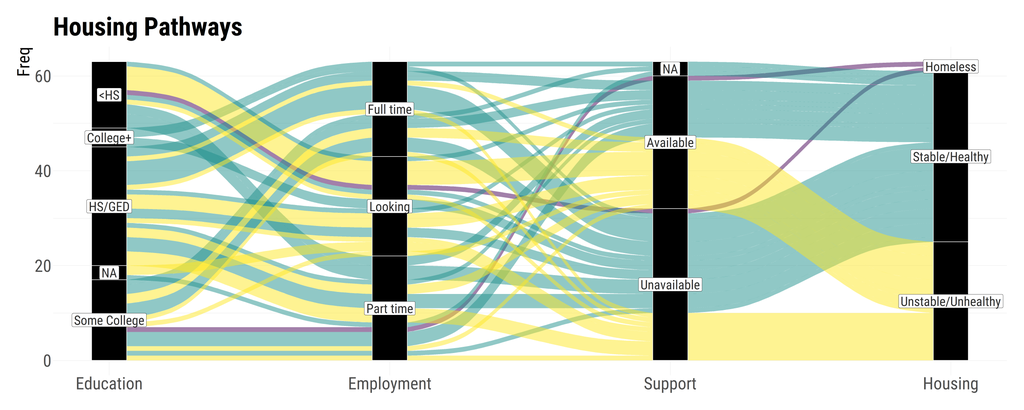

# Figure 4: Medication Access Alluvial

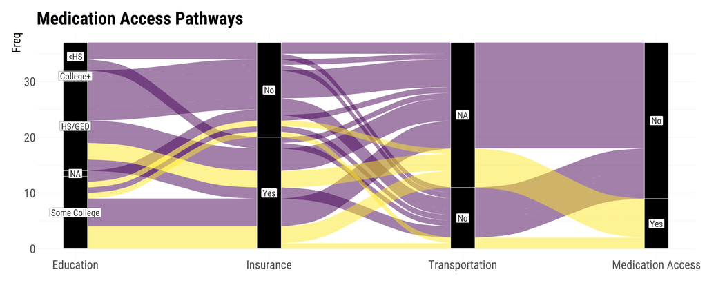